# hw6_mark

Ruizhou Peng

2023-11-18

load the package

```r
library(tidyverse)
```

## 1. Continuous random variables and limit laws

we will explore several continuous random variables and the limiting behaviours of sequences of i.i.d. random variables

### 1.1 Simulating data with the uniform distribution

**q1**:

$$\mathbb{P}(U\in [a,b]) = \mathbb{P}_U(x\in[0,1])*length([a,b]\cap
[0,1])\\
=1*(b-a)=b-a$$

**q2**:

X on {0,3,10}, P(X=3)=$\alpha$, P(X=10)=$\beta$, P(X=0)=$1-\alpha-\beta$

with $\alpha=\beta=0.25$, generate a sequence of i.i.d. X<sub>i</sub> of X:

```r
set.seed(0)
n <- 1000
# 0 --> P=0.5
# 3 --> P=0.25
# 10 --> P=0.25

sample_X <- data.frame(U=runif(n))%>%
  mutate(X=case_when(
    (0<=U)&(U<0.25)~3,
    (0.25<=U)&(U<0.5)~10,
    (0.5<=U)&(U<=1)~0
  ))%>%
  pull(X)
```

```r
head(sample_X,10)
```

```
##  [1]  0 10 10  0  0  3  0  0  0  0
```

proof: why does sample_X correspond to a sequence of i.i.d. copies X<sub>1</sub>, X<sub>2</sub>,…, X<sub>n</sub> of X?

Hint: finding P(X<sub>i</sub>=3),P(X<sub>i</sub>=10)… for the generated X<sub>i</sub>

ans:

for each X<sub>i</sub>, since it is independently generated from U, so they are independent and identical random variables. that is: P(X<sub>1</sub>)=P(X<sub>2</sub>)=…=P(X<sub>n</sub>)

since for each X<sub>i</sub>,

$$X_i = \begin{cases}
3, \quad U\in[0,0.25)\\
10, \quad U\in[0.25. 0.5)\\
0, \quad U\in [0.5, 1]
\end{cases}$$
due to U is a uniform distribution variable, the probability mass function of X<sub>i</sub> is:

$$P_{X_i}(x)=\begin{cases}
P_U(U\in[0,0.25))=0.25, \quad x=3\\
P_U(U\in[0.25,0.5))=0.25. \quad x=10\\
P_U(U\in[0.5,1])=0.5, \quad x=0 \\
P_U(U\notin [0,1])=0. \quad x\notin\{0,3,10\}
\end{cases}$$
it is the same as X, so X<sub>1</sub>, X<sub>2</sub>,…,X<sub>n</sub> are i.i.d. copies of X

**q3**:

create a function **sample_X_0310** which takes as inputs alpha, beta and n and outputs a sample X<sub>1</sub>,X<sub>2</sub>,…,X<sub>n</sub> copies of X where alpha=beta=0.25

```r
sample_X_0310 <- function(alpha, beta, n){
  sample_X <- runif(n)

  sample_X[0<=sample_X & sample_X<alpha] = 3
  sample_X[alpha<=sample_X & sample_X<alpha+beta] = 10
  sample_X[alpha+beta<=sample_X & sample_X<=1] = 0

  return(sample_X)
}

#check
sample_X_0310(0.25,0.25, 10)
```

```
##  [1] 10  0  0 10  0  3  3  0  0  0
```

**q4**:

let alpha=0.5, beta=0.1, use the function above to create a sample of size n=10000, what is the sample average of X<sub>n</sub>? How does this compare with the theoretical value of $\mathbb{E}(X)$?Then use the understanding of the law of large numbers to explain

ans:

```r
# first generate the sequence of Xi
seq_X <- sample_X_0310(0.5,0.1,10000)

# then compute the sample average
sample_average <- mean(seq_X)

print(sample_average)
```

```
## [1] 2.5118
```

the theoretical value of $\mathbb{E}(X)=\alpha*3+\beta*10=2.5$, which is very near the value of sample average.

According to the law of large numbers, when n goes large, the sample mean $\frac{\sum_{i=1}^n X_i}{n}$ of i.i.d. random variables X<sub>i</sub> converges to $\mathbb{E}(X)$

**q5**:

```r
# use the seq_X above to compute sample variance
sample_var <- var(seq_X)

print(sample_var)
```

```
## [1] 8.318093
```

the population variance Var(X) is: $Var(X)=9\alpha+100\beta-9\alpha^2-100\beta^2-60\alpha\beta\\=8.25$, this time the difference is also not much

**q6**:

now take n=100, $\alpha=0.1$ and vary $\beta$ from 0 to 0.9 with increment of 0.01, create a data frame with four columns: beta, sample_X, sample_mean, expectation

```r
n<-100
alpha <- 0.1

df <- data.frame(beta=seq(0,0.9,0.01))%>%
  mutate(sample_X=map(beta, ~sample_X_0310(alpha, .x, n)))%>%
  mutate(sample_mean=map_dbl(sample_X, mean))%>%
  mutate(Expectation=map_dbl(beta, ~.x*10+3*alpha))

# check
head(df,10)
```

```
##    beta
## 1  0.00
## 2  0.01
## 3  0.02
## 4  0.03
## 5  0.04
## 6  0.05
## 7  0.06
## 8  0.07
## 9  0.08
## 10 0.09
##                                                                                                                                                                                                                                                                                                          …
## 1             0, 0, 0, 0, 0, 0, 3, 0, 0, 0, 0, 0, 0, 0, 0, 0, 0, 0, 3, 0, 0, 0, 3, 3, 0, 0, 0, 0, 0, 0, 0, 0, 0, 0, 0, 0, 0, 0, 0, 0, 0, 0, 0, 0, 0, 0, 0, 0, 0, 0, 0, 0, 0, 0, 0, 0, 3, 0, 0, 0, 3, 0, 3, 0, 0, 0, 0, 0, 3, 0, 0, 0, 0, 0, 0, 0, 3, 0, 0, 0, 0, 0, 0, 0, 0, 0, 0, 0, 0, 0, 0, 0, 0, 3, 0…
## 2           0, 0, 0, 0, 0, 10, 0, 0, 0, 0, 3, 3, 0, 0, 0, 3, 0, 0, 0, 0, 0, 0, 0, 0, 0, 0, 0, 0, 0, 3, 0, 3, 0, 3, 0, 0, 3, 0, 3, 3, 0, 0, 3, 3, 0, 0, 0, 0, 3, 0, 0, 0, 3, 0, 0, 0, 0, 0, 0, 0, 3, 0, 0, 10, 3, 0, 0, 0, 0, 0, 0, 3, 0, 0, 0, 0, 3, 0, 0, 0, 0, 0, 0, 0, 0, 0, 0, 0, 0, 0, 0, 0, 0, 0, 0…
## 3         0, 0, 0, 0, 0, 0, 10, 0, 3, 0, 0, 0, 0, 0, 0, 0, 0, 0, 0, 0, 0, 0, 3, 0, 0, 0, 0, 3, 0, 0, 3, 0, 0, 10, 0, 3, 0, 3, 0, 0, 0, 0, 10, 3, 3, 0, 3, 0, 0, 0, 0, 0, 0, 0, 0, 0, 0, 0, 0, 0, 0, 0, 0, 3, 0, 0, 0, 0, 0, 0, 0, 3, 0, 0, 10, 0, 0, 0, 0, 3, 0, 0, 0, 0, 0, 0, 0, 0, 0, 0, 0, 0, 0, 0, 0…
```

[output cut: 18 more lines]

**q7**:

create a plot of the sample averages and $\mathbb{E}(X)$ as a function of $\beta$

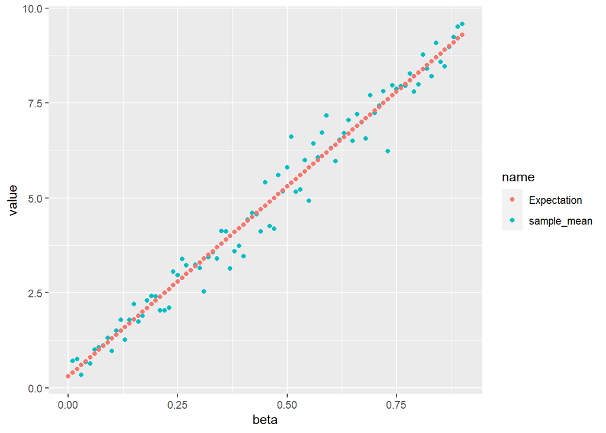

```r
# first tidy the df to be pivot longer
df_longer <- df%>%pivot_longer(cols=c(sample_mean,Expectation), names_to='name', values_to='value')

# then use point plot to show it
df_longer %>% ggplot(aes(x=beta, y= value, color=name))+
  geom_point()
```

### 1.2 Exponential distribution

**q1**:

proof:

$$\int_{-\infty}^{\infty} p_\lambda(x) =
\int_{-\infty}^00\;dx+\int_{0}^{+\infty}\lambda e^{-\lambda
x}\;dx=0-e^{-\lambda x}\;|_0^{+\infty}=1$$

so $p_\lambda (x)$ is well-defined probability density function

$$F_X(x) = p_\lambda(X\le x) = \int_{-\infty}^x\lambda e^{-\lambda x}\;dx
= -e^{-\lambda x} \; |_0^x = 1-e^{-\lambda x}$$

**q2**:

create a function **my_cdf_exp**, which takes two number x and $\lambda>0$ as input and output the cumulative distribution function F<sub>X</sub>(x) where X is an exponential random variable with rate parameter $\lambda$

```r
# x is a real number and lambda > 0
my_cdf_exp <- function(x, lambda){
  if(x < 0)
    return(0)

  res <- 1-exp(-lambda*x)

  return(res)
}

# check
lambda <- 1/2
map_dbl(.x=seq(-1,4), .f=~my_cdf_exp(.x, lambda))
```

```
## [1] 0.0000000 0.0000000 0.3934693 0.6321206 0.7768698 0.8646647
```

then learn function **pexp** for inbuilt cumulative distribution function of the exponential distribution

```r
test_inputs <- seq(-1, 10, 0.1)
# output of self create cdf function
my_cdf_output <- map_dbl(test_inputs, ~my_cdf_exp(.x, lambda))
# output of inbuilt cdf function:
# pexp-->distribution function of exponent distribution
inbuild_cdf_output <- map_dbl(test_inputs, ~pexp(.x, rate=lambda))

# compare two outputs
all.equal(inbuild_cdf_output, my_cdf_output)
```

```
## [1] TRUE
```

**q3**:

implement a function **my_quantile_exp**, which should take as input two arguments p$\in$[0,1] and $\lambda$>0, and output the value of the quantile function $F_X^{-1}(p)$ where X is an expomential random variable with rate parameter $\lambda$

```r
my_quantile_exp <- function(p, lambda){
  x <- log(1-p)/(-lambda)

  return(x)
}

# check with inbuilt function qexp
# qexp-->quantile of exponent distribution
seq_p <- seq(0.01, 0.99, 0.01)

# using self-made quantile function
my_qexp <- map_dbl(seq_p, ~my_quantile_exp(.x, lambda))

# using inbuilt quantile exponent function
inbuilt_qexp <- map_dbl(seq_p, ~qexp(.x, rate=lambda))

# compare
all.equal(my_qexp, inbuilt_qexp)
```

```
## [1] TRUE
```

**q4**:

derive an expression for the population mean and variance of an exponential random variable X with parameter $\lambda$

$$Var =
\mathbb{E}(X^2)-\mathbb{E}(X)^2=\int_{-\infty}^{+\infty}x^2P_X(x)dx-\frac{1}{\lambda^2}=\int_0^{+\infty}x^2
\lambda e^{-\lambda x}dx - \frac{1}{\lambda^2}\\
= \frac{1}{\lambda^2}\int_0^{+\infty}\lambda^2x^2e^{-\lambda x}d\lambda
x - \frac{1}{\lambda^2}\\
let \; z=\lambda x, \;\; z \in[0,+\infty)\\
\therefore Var= \frac{1}{\lambda^2}\int_0^{+\infty}z^2e^{-z}dz -
\frac{1}{\lambda^2}\\
let \; u = z^2, \; v = e^{-z}, \frac{du}{dz}=2z, \; \frac{dv}{dz} =
-e^{-z}\\
\therefore Var = \frac{-1}{\lambda^2}\int_0^{+\infty}u\frac{dv}{dz}dz -
\frac{1}{\lambda^2}\\
= \frac{-1}{\lambda^2}\left[ \int_0^{+\infty}u\frac{dv}{dz}dz +1
\right]\\
= \frac{-1}{\lambda^2}\left[ uv|_0^{+\infty} -
\int_0^{+\infty}v\frac{du}{dz}dz +1 \right]\\
= \frac{-1}{\lambda^2}\left[ uv|_0^{+\infty} -
2\int_0^{+\infty}ze^{-z}dz +1 \right]\\
= \frac{-1}{\lambda^2}\left[ 0 - 2 +1 \right]\\
= \frac{1}{\lambda^2}$$

### 1.3 The Binomial distribution and the central limit theorem

**q1**:

give an expression for the expectation and variance of Z~Binom(n,p)

ans:

since Binomial distribution is conducted from i.i.d. Bernoulli distribution random variables, and for Bernoulli distribution random variable X<sub>i</sub>, it has: $\mathbb{E}(X_i)=p \quad Var(X_i)=p-p^2$

therefore, for Z~Binom(n,p), its expectation and variance are:
$$E(Z) = nE(X_i)=np\\
Var(Z) = nVar(X_i)=np-np^2=np(1-p)$$

**q2**:

use **dbinom** to compute the probability mass function of a Binomial random variable Z~Binom(n,p), let n = 50, p = 0.7, use **dbinom** to generate a data frame **binom_df** with two columns x and pmf, the first contains the number {0,1,2,…,50}, the second perform the probability mass function p<sub>z</sub>(x)

```r
n <- 50
p <- 0.7

binom_df <- data.frame(x=0:50)%>%
  mutate(pmf=map_dbl(x, ~dbinom(.x, n, p)))

# check
head(binom_df, 5)
```

```
##   x          pmf
## 1 0 7.178980e-27
## 2 1 8.375477e-25
## 3 2 4.787981e-23
## 4 3 1.787513e-21
## 5 4 4.900764e-20
```

**q3**:

function **dnorm** can be used to compute the probability density function of a Gaussian random variable W~N(u, sig<sup>2</sup>)

consider a case where $\mu=50\cdot0.7$ and $\sigma=\sqrt{50\cdot 0.7\cdot(1-0.7)}$, use **dnorm** to generate a data frame **gaussian_df** with two columns x and pdf

```r
mu <- 50*0.7
sigma <- sqrt(50*0.7*(1-0.7))
gaussian_df <- data.frame(x=seq(0,50, 0.01))%>%
  mutate(pdf=map_dbl(x, ~dnorm(.x, mu, sigma)))

# check
head(gaussian_df, 5)
```

```
##      x          pdf
## 1 0.00 5.707825e-27
## 2 0.01 5.901264e-27
## 3 0.02 6.101201e-27
## 4 0.03 6.307852e-27
## 5 0.04 6.521440e-27
```

**q4**:

based on the **binom_df** and **gaussian_df**, generate a plot which compares the probability density for W and Z

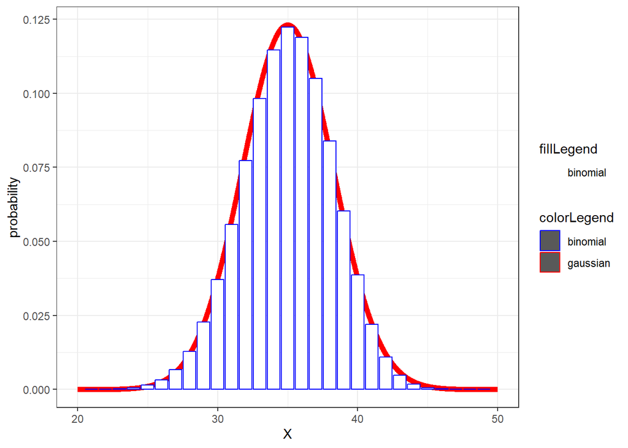

```r
# using different color and fill to show pdf and pmf
colors <- c('gaussian'='red', 'binomial'='blue')
fill <- c('gaussian'='white', 'binomial'='white')

# to show two different plots using one graph
# don't set data or aes in ggplot, otherwise, set them in
# the corresponding plot

# histogram is used to visualise a continuous variable
# for discrete variable, they should use geom_bar or geom_col
ggplot()+theme_bw()+
  geom_line(data=gaussian_df, aes(x=x, y=pdf, color='gaussian'), size=2, na.rm=TRUE)+
  geom_col(data=binom_df, aes(x=x, y=pmf, color='binomial', fill='binomial'), na.rm=TRUE)+
  #set color and fill
  scale_color_manual(name='colorLegend', values=colors)+
  scale_fill_manual(name='fillLegend', values=fill)+
  labs(x='X', y="probability")+
  # limit the x range
  xlim(c(20,50))
```

### 1.4 The Gaussian distribution

look up **dnorm**, **pnorm**, **qnorm** and **rnorm**

**q1**:

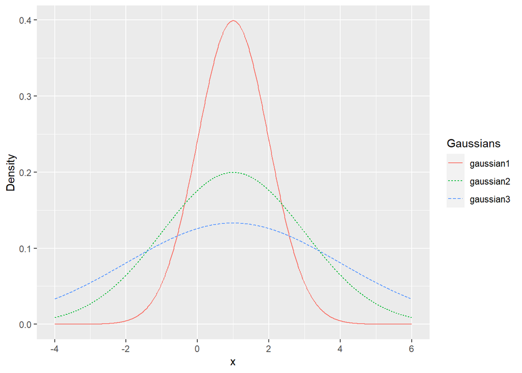

```r
mu1 <- 1
mu2 <- mu1
mu3 <- mu1

sigma1 <- 1
sigma2 <- 2
sigma3 <- 3
df_gaussians <- data.frame(x=seq(-4,6, 0.01))%>%
  mutate(gaussian1=map_dbl(x, ~dnorm(.x, mu1, sigma1)))%>%
  mutate(gaussian2=map_dbl(x, ~dnorm(.x, mu2, sigma2)))%>%
  mutate(gaussian3=map_dbl(x, ~dnorm(.x, mu3, sigma3)))

# now tidy it
df_gaussians_longer <- df_gaussians%>%pivot_longer(cols=!x, names_to = "Gaussians", values_to = "Density")

# now show the plot
df_gaussians_longer%>%ggplot(aes(x=x, y=Density, color=Gaussians,linetype=Gaussians))+
  geom_line()
```

**q2**:

generate a plot which displays the cumulative distribution function

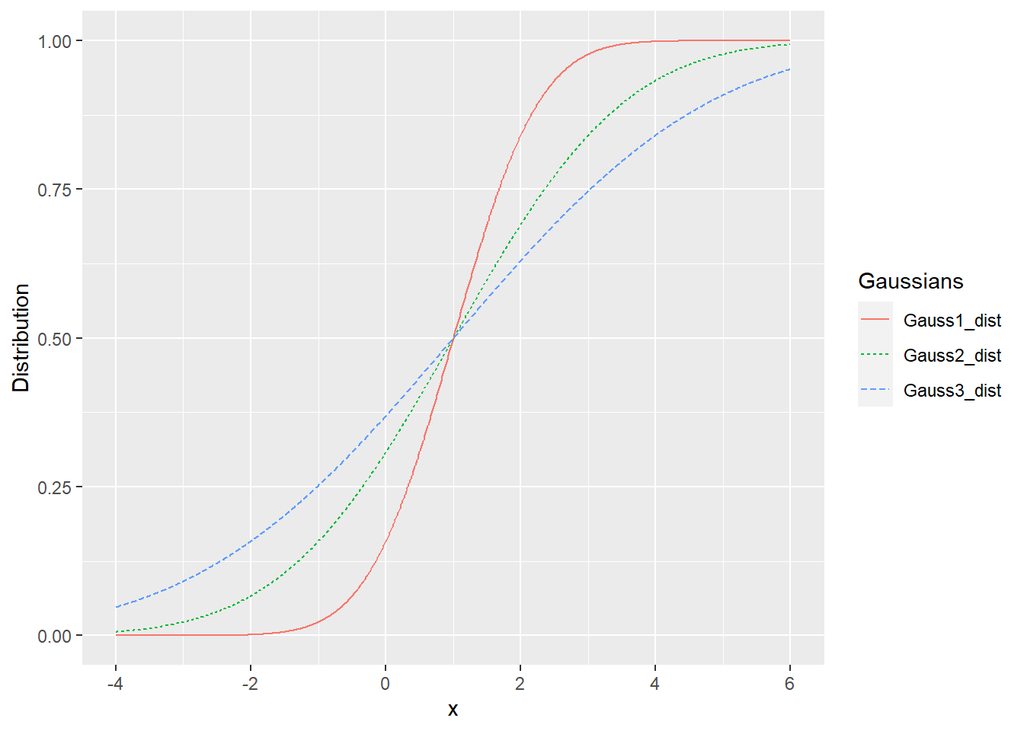

```r
df_gaussians <- df_gaussians%>%
  mutate(Gauss1_dist= map_dbl(x, ~pnorm(.x, mu1, sigma1)))%>%
  mutate(Gauss2_dist= map_dbl(x, ~pnorm(.x, mu2, sigma2)))%>%
  mutate(Gauss3_dist= map_dbl(x, ~pnorm(.x, mu3, sigma3)))

# tidy it
df_gaussians_longer2 <- df_gaussians%>%
  #select(!gaussian1:gaussian3)%>%
  pivot_longer(cols=Gauss1_dist:Gauss3_dist, values_to = "Distribution", names_to = "Gaussians")

# now show the plot
df_gaussians_longer2%>%ggplot(aes(x=x, y=Distribution, color=Gaussians,linetype=Gaussians))+
  geom_line()
```

**q3**:

generate the quantile function

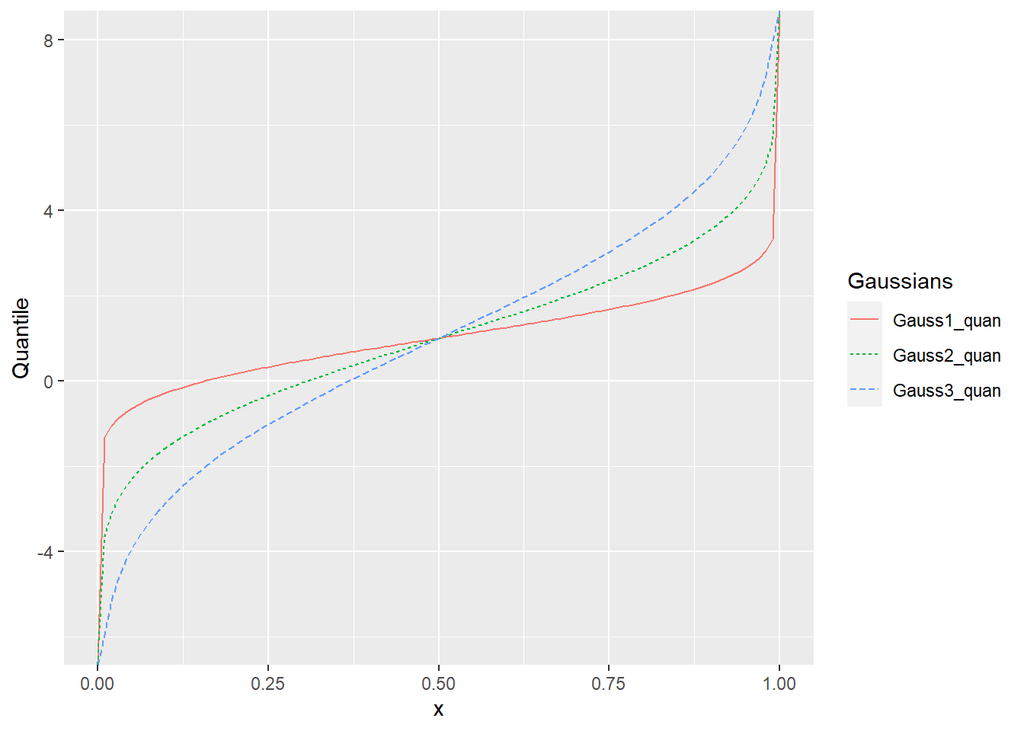

```r
df_gaussians <- df_gaussians%>%
  mutate(Gauss1_quan= map_dbl(x, ~qnorm(.x, mu1, sigma1)))%>%
  mutate(Gauss2_quan= map_dbl(x, ~qnorm(.x, mu2, sigma2)))%>%
  mutate(Gauss3_quan= map_dbl(x, ~qnorm(.x, mu3, sigma3)))
# tidy it
df_gaussians_longer3 <- df_gaussians%>%
  #select(!gaussian1:gaussian3)%>%
  pivot_longer(cols=Gauss1_quan:Gauss3_quan, values_to = "Quantile", names_to = "Gaussians")

# now show the plot
df_gaussians_longer3%>%ggplot(aes(x=x, y=Quantile, color=Gaussians,linetype=Gaussians))+
  geom_line(na.rm = TRUE)+xlim(0,1)
```

the quantile function and cumulative distribution function are complementary functions

**q4**:

use **rnorm** to generate a random i.i.d. sequence Z<sub>1</sub>,Z<sub>2</sub>,…,Z<sub>n</sub> $\sim N(0,1)$, set n=100, store the random sample in a vector

```r
n <- 100
set.seed(0)
standardGaussianSample <- rnorm(n, 0, 1)

# check
head(standardGaussianSample, 10)
```

```
##  [1]  1.262954285 -0.326233361  1.329799263  1.272429321  0.414641434
##  [6] -1.539950042 -0.928567035 -0.294720447 -0.005767173  2.404653389
```

**q5**:

generate a new sample of the form Y1, Y2, …, Yn $\sim N(1,3)$ and store them in **mean1Var3GaussianSampleA**, use **standardGaussianSample** with $\alpha,\; \beta$ transform to it

ans:

if $Z\sim N(0,1)$ and $W = \alpha Z+\beta$, then $W\sim N(\beta,\alpha^2)$, now to compute $Y\sim N(1,3)$, let $\beta=1,\;\alpha=\sqrt{3}$

```r
mean1Var3GaussianSampleA <- sqrt(3)*standardGaussianSample+1
```

**q6**:

use **rnorm** to generate Y<sub>1</sub>, Y<sub>2</sub>, …, Y<sub>n</sub> and compare with the vector above

```r
set.seed(0)
mean1Var3GaussianSampleB <- rnorm(n, 1, sqrt(3))

all.equal(mean1Var3GaussianSampleA, mean1Var3GaussianSampleB)
```

```
## [1] TRUE
```

**q7**:

generate a graph which includes both a kernel density with mean1Var3GaussianSampleA and the population density generated from **dnorm**.

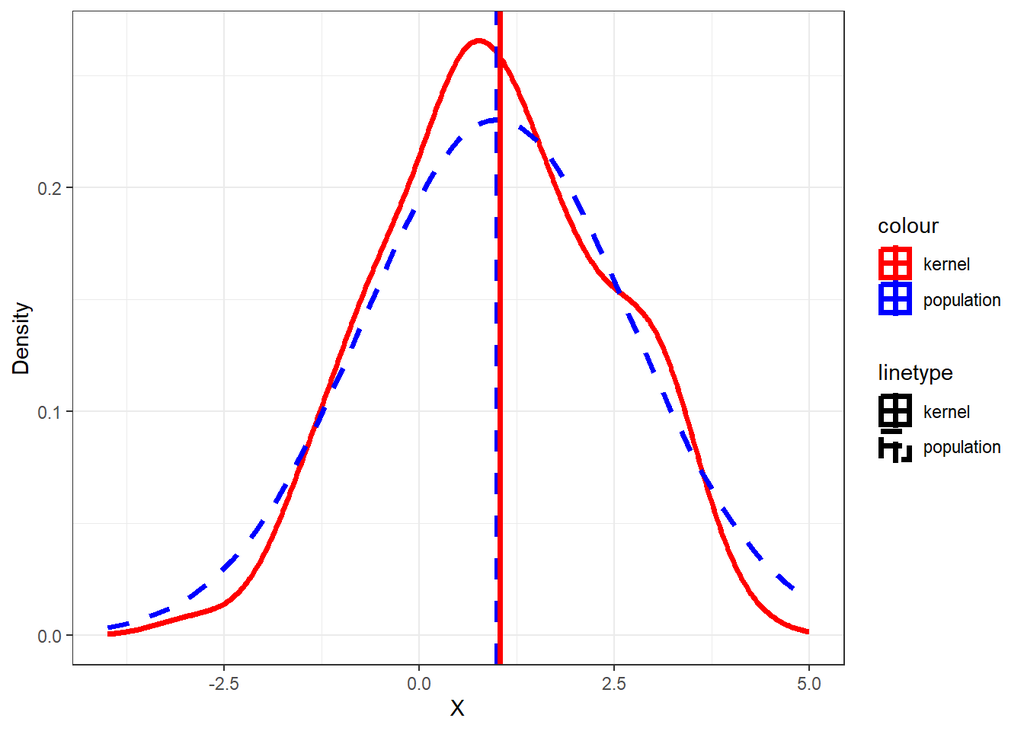

```r
# use geom_density to show the kernel density
# geom_vline to show the mean of kernel density and population density
Size <- 1.25
colors <- c('kernel'='red', 'population'='blue')
linetypes <- c('kernel'='solid', 'population'='dashed')

df_kernel <- data.frame(x=1:n, samples=mean1Var3GaussianSampleA)
df_population <- data.frame(x=seq(-5,5,0.1))%>%
  mutate(density=map_dbl(x, ~dnorm(.x, 1, sqrt(3))))

kernel_mean = mean(df_kernel%>%pull(samples), na.rm = TRUE)
# use geom_density to show kernel density
ggplot()+theme_bw()+labs(x='X', y='Density', legend='Legend')+
  geom_density(data=df_kernel, aes(samples, color='kernel', linetype='kernel'),size=Size)+
  geom_line(data=df_population, aes(x=x, y=density, color='population', linetype='population'),size=Size, na.rm = TRUE)+
  geom_vline(aes(xintercept = 1,color='population',linetype='population'),size=Size)+
  geom_vline(aes(xintercept = kernel_mean, color='kernel',linetype='kernel'),size=Size)+
  scale_color_manual(values = colors)+
  xlim(c(-4,5))+
  scale_linetype_manual(values= linetypes)
```

**q8**:

derive P(c<= W <= d) from P(a<=X<=b) and W=$\alpha X+\beta$ with X~N(0,1)

to prove it holds, then prove the following expression is a Gaussian distribution
$$P(c\le W\le d)=\int_c^d
\frac{1}{\sigma\sqrt{2\pi}}e^{\frac{-1}{2}(\frac{w-\mu}{\sigma})^2}dw$$

## 2. Location estimators with Gaussian data

compare two estimators for the population mean $\mu_0$ in a Gaussian setting in which we have i.i.d. data X<sub>1</sub>,X<sub>2</sub>,…,X<sub>n</sub> $\sim N(\mu_0, \sigma_0^2)$

compute a data frame consisting of the mean square error of the sample median as an estimator of $\mu_0$

```r
set.seed(0)
num_trials_per_sample_size <- 1000
min_sample_size <- 30
max_sample_size <- 500
sample_size_inc <- 5
mu_0 <- 1
sigma_0 <- 3

# create data frame of all pairs of sample_size and trial

# review crossing, expand and nesting
simulation_df<-crossing(trial=seq(num_trials_per_sample_size),
                        sample_size=seq(min_sample_size,
                                        max_sample_size,sample_size_inc))%>%
  # simulate sequences of Gaussian random variables
  # .y means the second argument in the pmap function
  mutate(simulation=pmap(.l=list(trial,sample_size),
                        .f=~rnorm(.y,mean=mu_0,sd=sigma_0)))%>%
  # compute the sample medians
  mutate(sample_md=map_dbl(.x=simulation,.f=median))%>%
  group_by(sample_size) %>%
  summarise(msq_error_md=mean((sample_md-mu_0)^2))
```

**q1**:

derive the mathematical expression for the population median of a Gaussian variable X<sub>i</sub> $\sim N(\mu_0, \sigma_0^2)$

$$let \ m <- mean\\
F_{X_i}(x) =
\int_{-\infty}^{x}\frac{1}{\sqrt{2\pi\sigma^2}}e^{-\frac{(t-\mu_0)^2}{2\sigma^2}}dt=0.5\\
= \frac{1}{2}[1 + \text{erf}(\frac{x - \mu_0}{\sigma_0\sqrt{2}})] \quad
where \;\; \text{erf}(x) = \frac{2}{\sqrt{\pi}} \int_{0}^{x} e^{-t^2}
dt\\
\therefore0=\text{erf}(\frac{x - \mu_0}{\sigma_0\sqrt{2}})\\
\because the \ error\ function\ equals\ 0 \ at\ (x=0)\\
\therefore \frac{m-\mu_0}{\sqrt{2}\sigma_0}=0\\
\therefore m=\mu_0$$
solution to solve erf:

$$I^2 = \left(\int_{-\infty}^{+\infty}e^{-k^2}dk\right)^2$$
This can be rewritten as a double integral:

$$I^2 = \int_{-\infty}^{+\infty}\int_{-\infty}^{+\infty}e^{-(x^2+y^2)}dxdy$$

Now, we switch to polar coordinates using $x = r\cos(\theta)$ and $y = r\sin(\theta)$, and $dxdy = rdrd\theta$. The limits of integration for (r) are from 0 to $\infty$, and for $\theta$ are from 0 to $2\pi$. So, the double integral becomes:

$$I^2 = \int_{0}^{2\pi}\int_{0}^{\infty}r e^{-r^2}drd\theta$$
The integral with respect to (r) can be solved by substituting $u = r^2$, which gives $du = 2rdr$. The integral then simplifies to:

$$I^2 = \int_{0}^{2\pi}\int_{0}^{\infty}\frac{1}{2} e^{-u}dud\theta = \pi$$

Taking the square root of both sides gives the original integral:

$$I = \sqrt{\pi}$$
**q2**:

modify the above code to include estimates of the mean square error of the sample mean with a new column **msq_error_mn**, then generate a plot which includes both the mean square error of the sample mean and the sample median

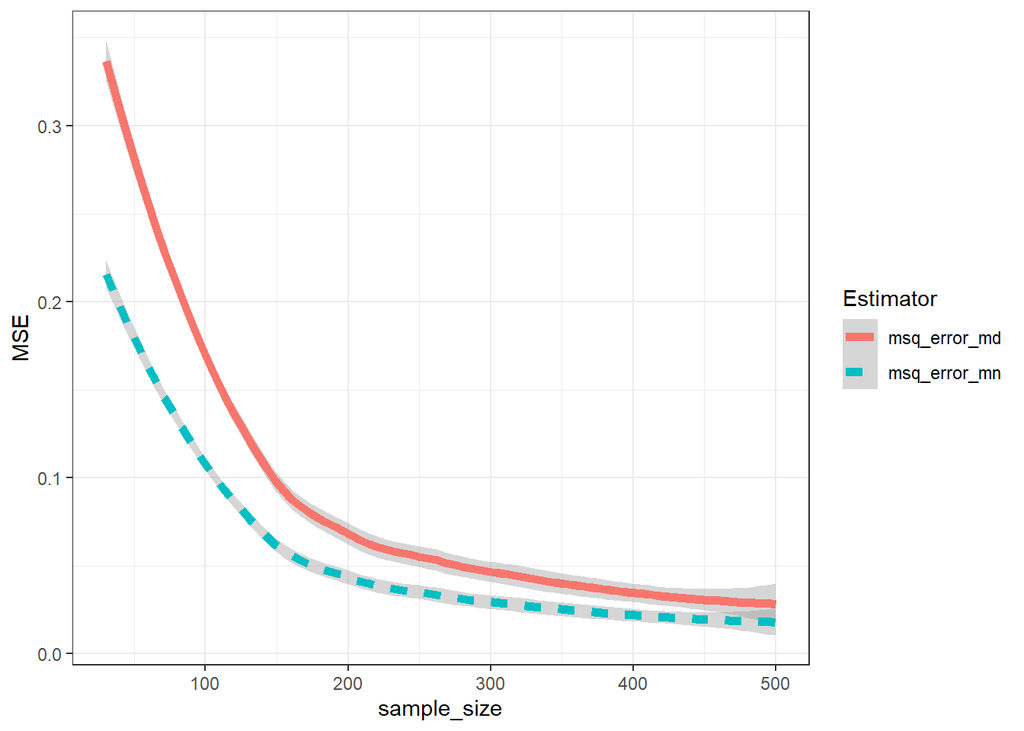

```r
set.seed(0)
num_trials_per_sample_size <- 1000
min_sample_size <- 30
max_sample_size <- 500
sample_size_inc <- 5
mu_0 <- 1
sigma_0 <- 3

# create data frame of all pairs of sample_size and trial
# review crossing, expand and nesting
simulation_df<-crossing(trial=seq(num_trials_per_sample_size),
                        sample_size=seq(min_sample_size,
                                        max_sample_size,sample_size_inc))%>%
  # simulate sequences of Gaussian random variables
  # .y means the second argument in the pmap function
  mutate(simulation=pmap(.l=list(trial,sample_size),
                        .f=~rnorm(.y,mean=mu_0,sd=sigma_0)))%>%
  # compute the sample medians
  # !!!!and sample mean!!!!
  mutate(sample_md=map_dbl(.x=simulation,.f=median),
         sample_mn=map_dbl(.x=simulation,.f=mean))%>%
  group_by(sample_size) %>%
  # compute the msq_error of median and mean
  summarise(msq_error_md=mean((sample_md-mu_0)^2),
            msq_error_mn=mean((sample_mn-mu_0)^2))

# tidy it
simulation_df_long <- simulation_df%>%pivot_longer(cols=!sample_size, names_to = "Estimator", values_to =  "MSE")

# using plot to show it
# instead of using geom_line, we can use geom_smooth to show curve
simulation_df_long%>%ggplot(aes(x=sample_size, y=MSE, color=Estimator, linetype=Estimator))+theme_bw()+geom_smooth(size=2)
```

## 3. The law of large numbers and Hoeffding’s inequality

Theorem (A law of large numbers):

$$lim_{n->\infty} \mathbb{P}(|\frac{1}{n}\sum_{i=1}^n X_i-\mu|\ge
\epsilon) = 0$$

Chebyshev’s inequality:

$$\mathbb{P}(|Z-\mathbb{E}(Z)\ge t|)\le Var(Z)/t^2$$

Theorem (Hoeffding): let X: $\Omega -> [0,1]$ be a bounded random variable

$$\mathbb{P}(|\frac{1}{n}\sum_{i=1}^n X_i-\mu|\ge \epsilon)\le
e^{-2n\epsilon^2}$$